# Homework 5

Nick Matthews; nickmatthews713

4/8/2020

## Liquor Sales in Iowa

This dataset https://data.iowa.gov/Sales-Distribution/2019-Iowa-Liquor-Sales/38x4-vs5h contains the spirits purchase information of Iowa Class “E” liquor licensees by product and date of purchase for 2019. The dataset can be used to analyze total spirits sales in Iowa of individual products at the store level.

**Submission instructions**: Create a folder named `ds202_hw5`, and name the RMarkDown file including your solutions `hw5.Rmd` under this folder. For the submission, create a GitHub repository named `ds202_hw5` under your GitHub account, and push both `hw5.Rmd` and the knitted `hw5.html` before the deadline. I will assume you use the same GitHub username as for your HW4 submission. The latest version of your homework appearing on GitHub before the deadline is graded. *It is crucial to follow the exact folder structure and file names*, so that your homework can be reproduced and graded by an automated script. This homework is **due on April 10** by 11:59 pm.

1. The complete dataset is too large. Download and import the alcohol sales data for Ames only:
1. Go to https://data.iowa.gov/Sales-Distribution/2019-Iowa-Liquor-Sales/38x4-vs5h
2. Click Filter – Filter – Go advanced now
3. Add a New Filter Condition: City is Ames.
4. Export – CSV – Download
5. Use `readr::read_csv` to import.

```r
library(dplyr)
library(tidyr)
library(stringr)
library(lubridate)
library(ggplot2)

sales <- readr::read_csv("2019_Iowa_Liquor_Sales.csv")
```

2. Data cleaning:
1. extract geographic latitude and longitude from the variable `Store Location`
2. make sure the variables are in the correct type, by converting incorrect variable types.
3. extract year, month and day from the variable `Date` as separate columns.

```r
# All 3 problems are done here
sales <- sales %>%
  mutate("Store Location" = str_extract(sales$`Store Location`, '(?<=POINT \\()(.*)(?=\\))')) %>%
  separate("Store Location", into = c("lat","long"), sep = " ", convert = TRUE) %>%
  mutate(year = year(mdy(Date)), month = month(mdy(Date)), day = day(mdy(Date)))
```

3. First overview:
1. Plot a scatterplot of lat and long of store locations.
2. Provide a visual breakdown of the liquor category (by `Category Name`). Include volume sold in the breakdown.

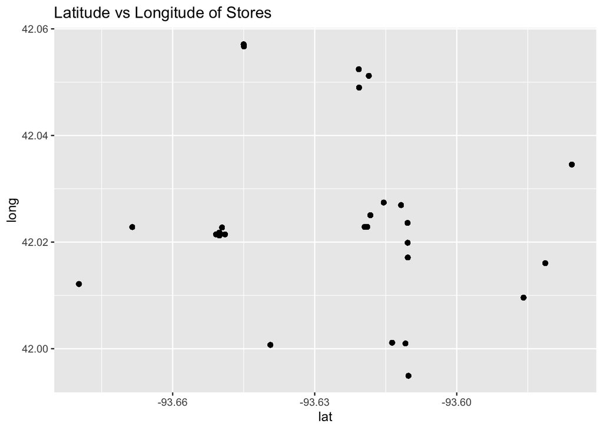

```r
sales %>%
  ggplot(aes(x=lat, y=long)) + geom_point() + ggtitle("Latitude vs Longitude of Stores")
```

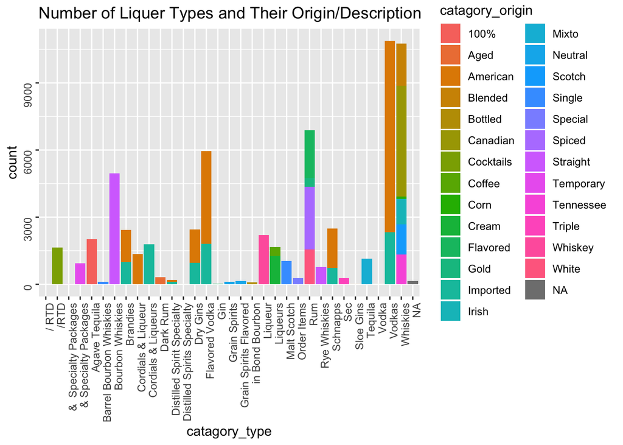

```r
sales %>%
  mutate(catagory_origin = str_extract(sales$`Category Name`, '^(\\S+\\s+\\n?){1}')) %>%
  mutate(catagory_type = str_extract(sales$`Category Name`, '(?<= ).*')) %>%
  group_by(catagory_type, catagory_origin) %>%
  summarise(count = n()) %>%
  ggplot(aes(x=catagory_type, y=count, fill = catagory_origin)) +
  geom_bar(stat = "identity", position = "stack") + theme(axis.text = element_text(angle=90, hjust = 1)) +
  ggtitle("Number of Liquer Types and Their Origin/Description")
```

### Description:

I noticed that each “Category Name” has a prefix which reveals that liquers origin or description, while the rest of the “Category Name” revealed the actual liquer type. So, I split the two into columns, summarized them, and plotted it. As you can see, there are the same liquer types that come from different origins. For example, if you look at Flavored Vodka, some is imported and some is American

4. Find the daily sales liquor sales in Ames in 2019. Summarize the number of sales, volume of liquor sold, and amount of money spent.

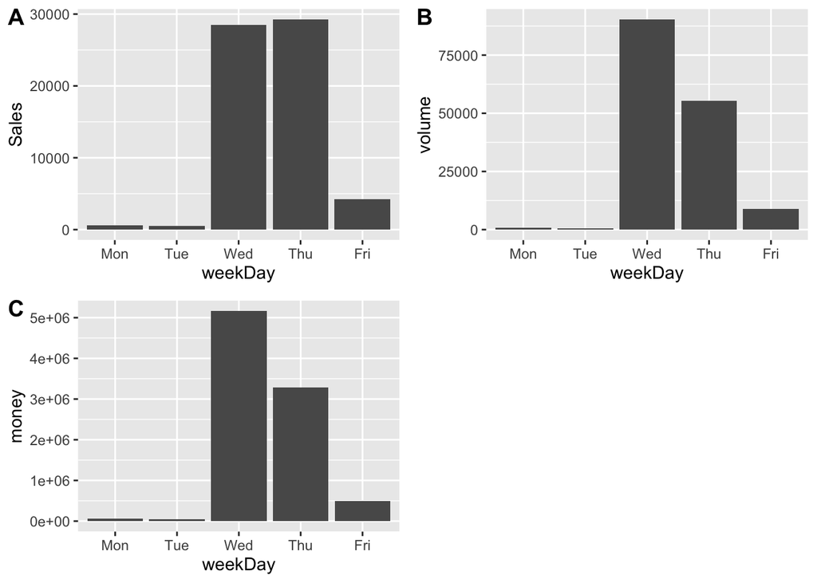

```r
sales2019 <- sales %>%
  filter(year == 2019)

sales2019 <- sales2019 %>%
  mutate(weekDay = wday(mdy(Date), label = TRUE))

sales2019Summ <- sales2019 %>%
  group_by(weekDay) %>%
  summarise(Sales = n(), volume = sum(`Volume Sold (Gallons)`), money = sum(`Sale (Dollars)`))

library(cowplot)

salesPlot <- sales2019Summ %>%
  ggplot(aes(x=weekDay, y=Sales)) + geom_bar(stat = "identity")

volumePlot <- sales2019Summ %>%
  ggplot(aes(x=weekDay, y=volume)) + geom_bar(stat = "identity")

moneyPlot <- sales2019Summ %>%
  ggplot(aes(x=weekDay, y=money)) + geom_bar(stat = "identity")

plot_grid(salesPlot,volumePlot,moneyPlot, labels = "AUTO")
```

### Description:

I decided to make the analysis a little more extensive and summarize each day of the week, so I used cowplot to make 3 barplots that give me the values (sales, volume, and money)

5. Plot volume sold by day (use a scatterplot of volume by day and facet by month). Discover trends with the help of `geom_smooth`. Describe any patterns.

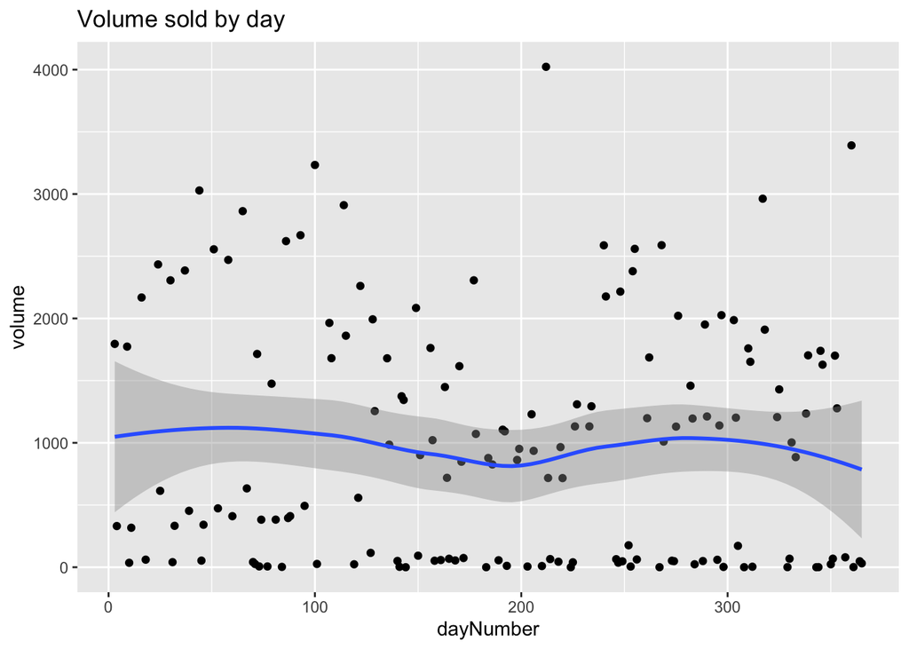

```r
sales2019 %>%
  mutate(dayNumber = yday(mdy(Date))) %>%
  group_by(dayNumber) %>%
  summarise(volume = sum(`Volume Sold (Gallons)`)) %>%
  ggplot(aes(x=dayNumber, y=volume)) + geom_point() +
  ggtitle("Volume sold by day") + geom_smooth()
```

### Description:

First, I grouped by the number of day of the year, then I summarized the amount sold that day. I’m guessing all of the dots floating toward the top of the plot represent holidays. I used geom_smooth to get a trendline. So, from my holiday assumption, you could also say that where the line is higher, there are more holidays condensed at that time.

6. Find the dates for ISU football home games in Fall 2019. Can you see a pattern?